# LPD vs. Experimental Structural Divergence

# Introduction

In this report we compare different LPD measures (their inverse, 1/CN and 1/WCN), with mean SDi experimental profiles. We do this because theoretical mean SDi is proportional to 1/CN or 1/WCN (depending on the ENM used to generate mutants). Then, using different R0 to calculate CN, we can get an idea of the results that will come from the simulations and choose some values of R0 to generate mutants. Theoretical SDi of ANM is proportional to 1/CN with an r of aprox. 0.97, meanwhile theoretical SDi of pfANM is proportional to 1/WCN with a lower value of r. To calculate LPD measures, we used only CA of aa (“CA”), and both CA and CM (“CM”).

p = pearson correlation coef, s = spearman correlation coef.

In this case we studied the snakesToxin family. We used as reference for the ENM the protein with pdb code 1ntx. The snakesToxin family is of the type small and consists of the following proteins:

```
##  [1] "2crt"  "2cdx"  "1cdta" "1tgxa" "1kxia" "1tfs"  "1drs"  "1txb"
##  [9] "2ctx"  "1ntn"  "1lsi"  "2abxa" "2nbta" "1nean" "1nor"  "1cod"
## [17] "1nxb"  "1fas"  "1kbt"
```

### CA comparison

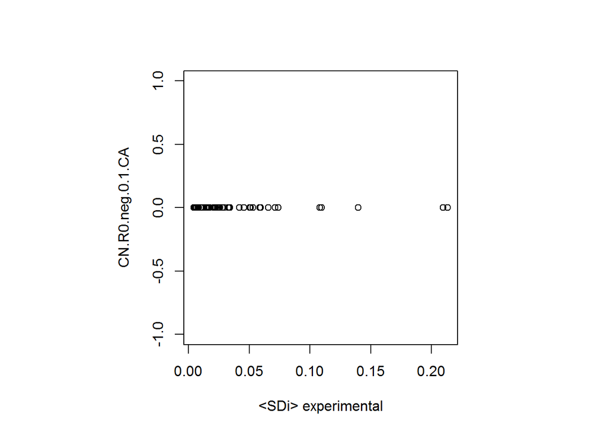

Pearson Correlation structure (SDi) - sequence (CN)

| comparison | R |
| --- | --- |
| experimental vs CN | NA |

Pearson Correlation sqrt structure (SDi) - sqrt sequence (CN)

| comparison | R |
| --- | --- |
| experimental vs CN | NA |

Spearman Correlation structure (SDi) - sequence (CN)

| comparison | R |
| --- | --- |
| experimental vs CN | NA |

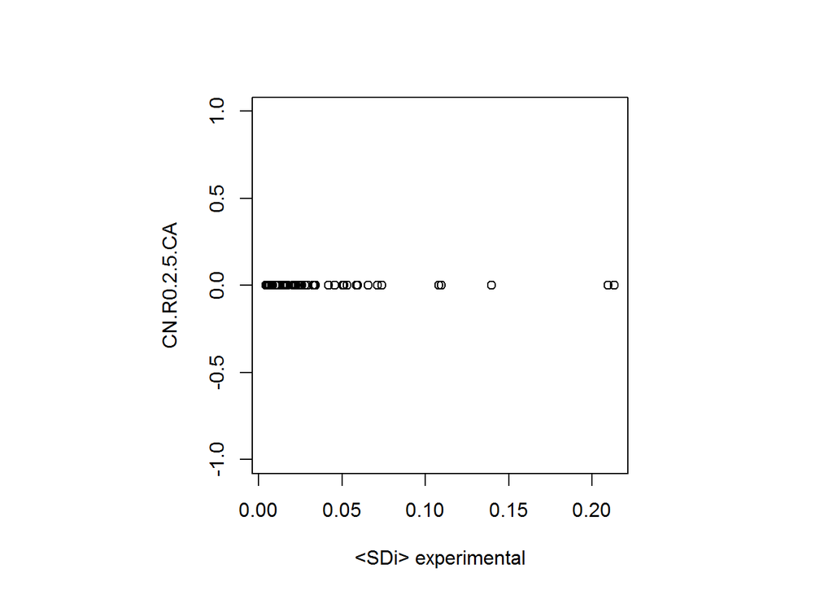

Pearson Correlation structure (SDi) - sequence (CN)

| comparison | R |
| --- | --- |
| experimental vs CN | NA |

Pearson Correlation sqrt structure (SDi) - sqrt sequence (CN)

| comparison | R |
| --- | --- |
| experimental vs CN | NA |

Spearman Correlation structure (SDi) - sequence (CN)

| comparison | R |
| --- | --- |
| experimental vs CN | NA |

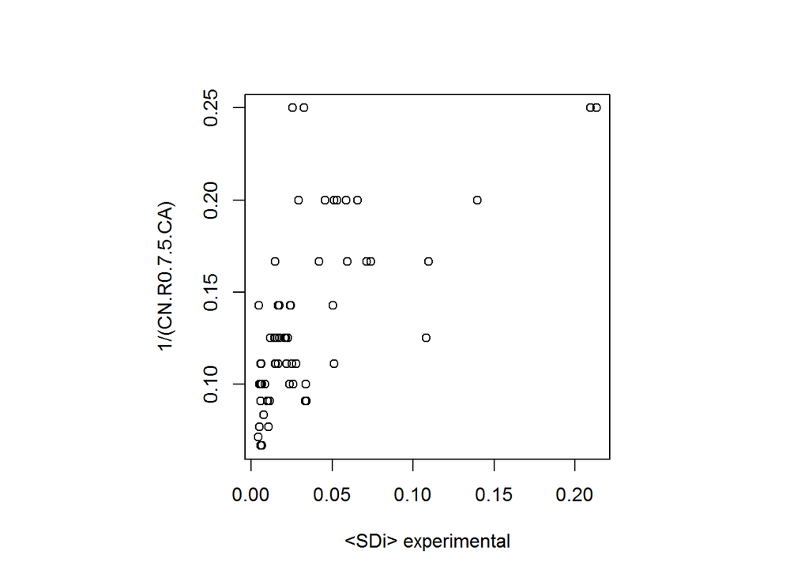

Pearson Correlation structure (SDi) - sequence (CN)

| comparison | R |
| --- | --- |
| experimental vs 1/(CN) | 0.65 |

Pearson Correlation sqrt structure (SDi) - sqrt sequence (CN)

| comparison | R |
| --- | --- |
| experimental vs CN | 0.7 |

Spearman Correlation structure (SDi) - sequence (CN)

| comparison | R |
| --- | --- |
| experimental vs 1/(CN) | 0.68 |

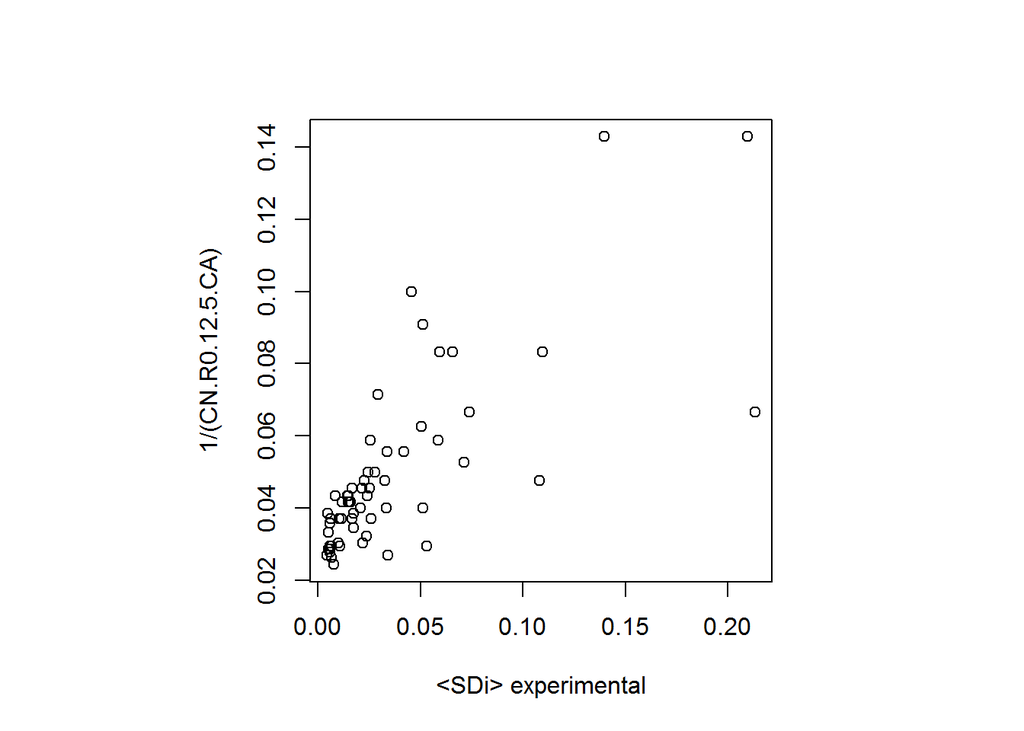

Pearson Correlation structure (SDi) - sequence (CN)

| comparison | R |
| --- | --- |
| experimental vs 1/(CN) | 0.74 |

Pearson Correlation sqrt structure (SDi) - sqrt sequence (CN)

| comparison | R |
| --- | --- |
| experimental vs CN | 0.77 |

Spearman Correlation structure (SDi) - sequence (CN)

| comparison | R |
| --- | --- |
| experimental vs 1/(CN) | 0.75 |

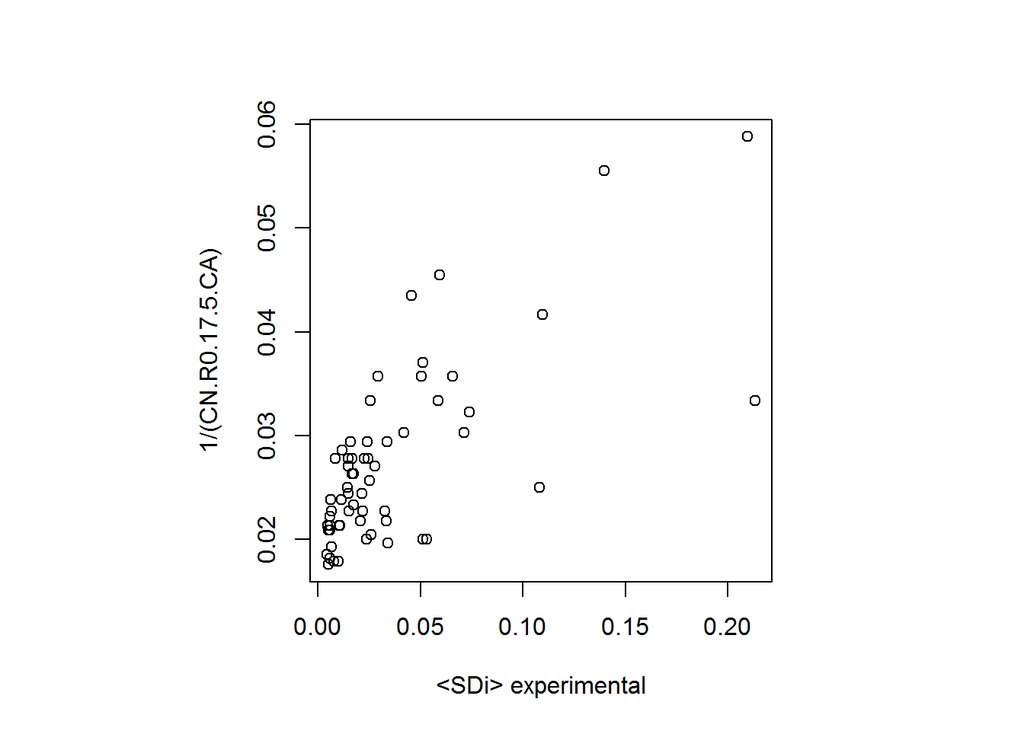

Pearson Correlation structure (SDi) - sequence (CN)

| comparison | R |
| --- | --- |
| experimental vs 1/(CN) | 0.71 |

Pearson Correlation sqrt structure (SDi) - sqrt sequence (CN)

| comparison | R |
| --- | --- |
| experimental vs CN | 0.72 |

Spearman Correlation structure (SDi) - sequence (CN)

| comparison | R |
| --- | --- |
| experimental vs 1/(CN) | 0.64 |

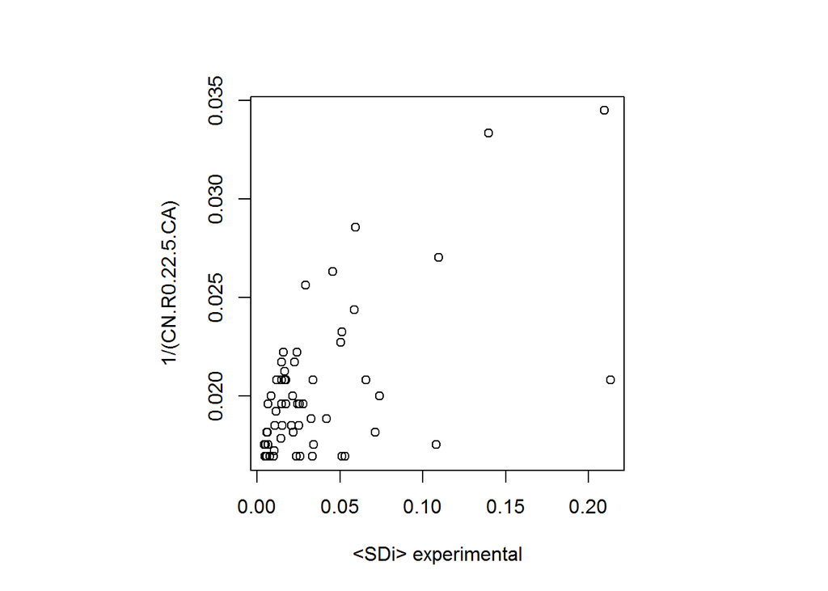

Pearson Correlation structure (SDi) - sequence (CN)

| comparison | R |
| --- | --- |
| experimental vs 1/(CN) | 0.61 |

Pearson Correlation sqrt structure (SDi) - sqrt sequence (CN)

| comparison | R |
| --- | --- |
| experimental vs CN | 0.61 |

Spearman Correlation structure (SDi) - sequence (CN)

| comparison | R |
| --- | --- |
| experimental vs 1/(CN) | 0.47 |

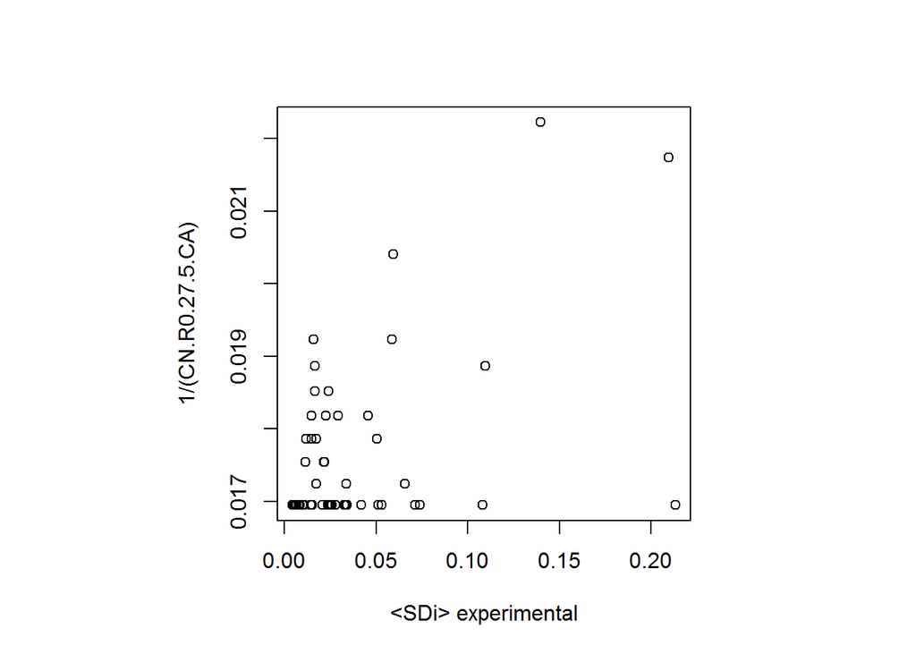

Pearson Correlation structure (SDi) - sequence (CN)

| comparison | R |
| --- | --- |
| experimental vs 1/(CN) | 0.5 |

Pearson Correlation sqrt structure (SDi) - sqrt sequence (CN)

| comparison | R |
| --- | --- |
| experimental vs CN | 0.49 |

Spearman Correlation structure (SDi) - sequence (CN)

| comparison | R |
| --- | --- |
| experimental vs 1/(CN) | 0.32 |

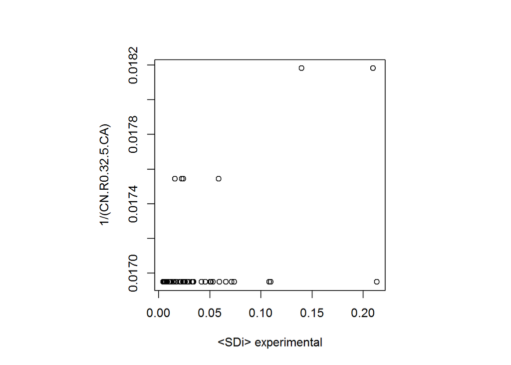

Pearson Correlation structure (SDi) - sequence (CN)

| comparison | R |
| --- | --- |
| experimental vs 1/(CN) | 0.5 |

Pearson Correlation sqrt structure (SDi) - sqrt sequence (CN)

| comparison | R |
| --- | --- |
| experimental vs CN | 0.45 |

Spearman Correlation structure (SDi) - sequence (CN)

| comparison | R |
| --- | --- |
| experimental vs 1/(CN) | 0.25 |

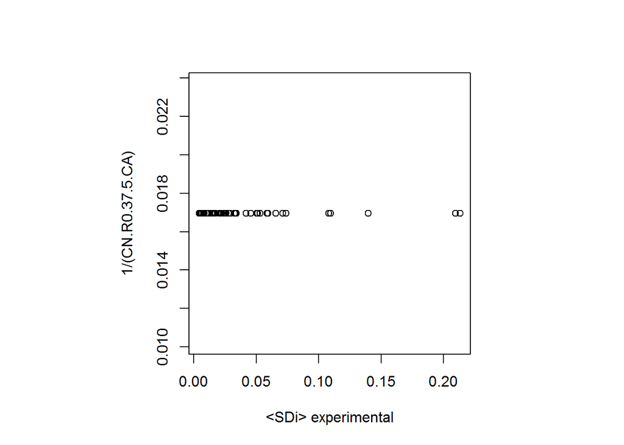

Pearson Correlation structure (SDi) - sequence (CN)

| comparison | R |
| --- | --- |
| experimental vs 1/(CN) | NA |

Pearson Correlation sqrt structure (SDi) - sqrt sequence (CN)

| comparison | R |
| --- | --- |
| experimental vs CN | NA |

Spearman Correlation structure (SDi) - sequence (CN)

| comparison | R |
| --- | --- |
| experimental vs 1/(CN) | NA |

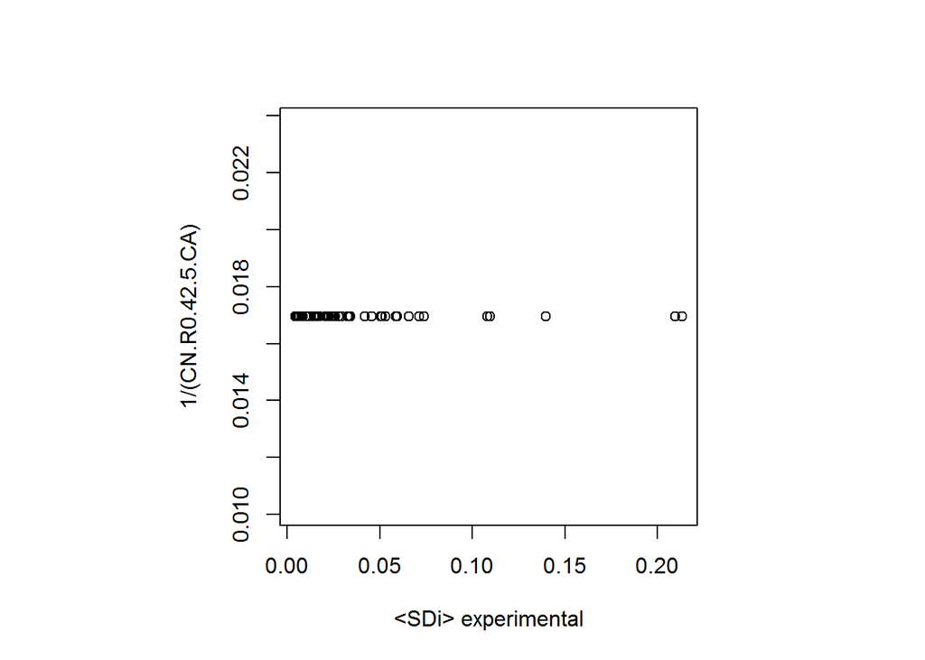

Pearson Correlation structure (SDi) - sequence (CN)

| comparison | R |
| --- | --- |
| experimental vs 1/(CN) | NA |

Pearson Correlation sqrt structure (SDi) - sqrt sequence (CN)

| comparison | R |
| --- | --- |
| experimental vs CN | NA |

Spearman Correlation structure (SDi) - sequence (CN)

| comparison | R |
| --- | --- |
| experimental vs 1/(CN) | NA |

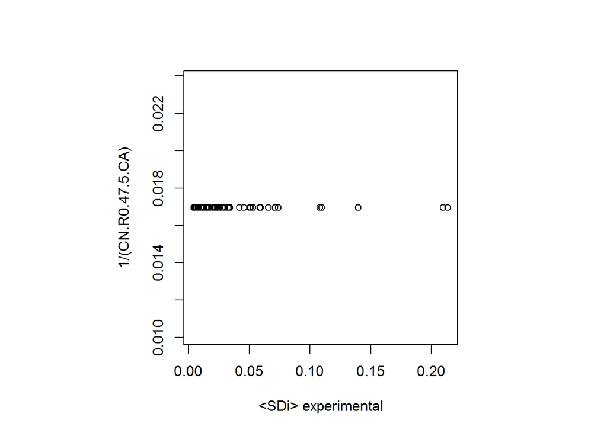

Pearson Correlation structure (SDi) - sequence (CN)

| comparison | R |
| --- | --- |
| experimental vs 1/(CN) | NA |

Pearson Correlation sqrt structure (SDi) - sqrt sequence (CN)

| comparison | R |
| --- | --- |
| experimental vs CN | NA |

Spearman Correlation structure (SDi) - sequence (CN)

| comparison | R |
| --- | --- |
| experimental vs 1/(CN) | NA |

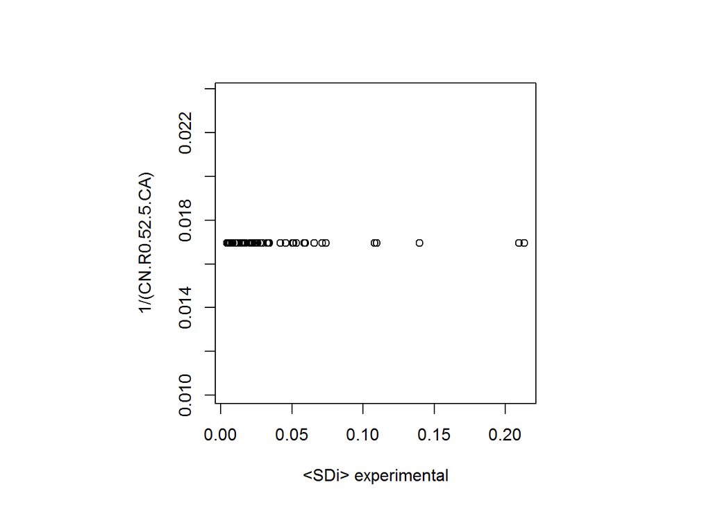

Pearson Correlation structure (SDi) - sequence (CN)

| comparison | R |
| --- | --- |
| experimental vs 1/(CN) | NA |

Pearson Correlation sqrt structure (SDi) - sqrt sequence (CN)

| comparison | R |
| --- | --- |
| experimental vs CN | NA |

Spearman Correlation structure (SDi) - sequence (CN)

| comparison | R |
| --- | --- |
| experimental vs 1/(CN) | NA |

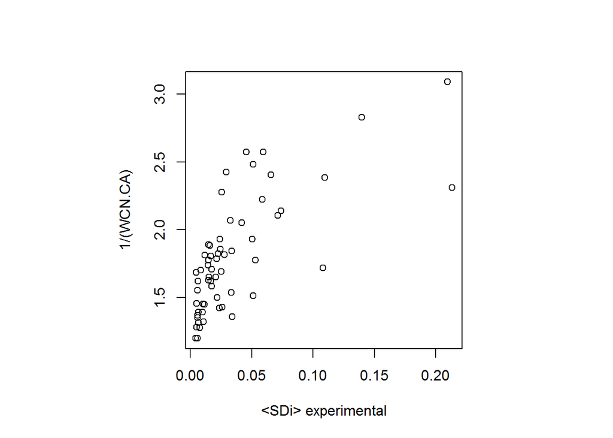

Pearson Correlation structure (SDi) - sequence (WCN)

| comparison | R |
| --- | --- |
| experimental vs 1/(WCN) | 0.71 |

Pearson Correlation sqrt structure (SDi) - sqrt sequence (WCN)

| comparison | R |
| --- | --- |
| experimental vs 1/(WCN) | 0.76 |

Spearman Correlation structure (SDi) - sequence (WCN)

| comparison | R |
| --- | --- |
| experimental vs 1/(WCN) | 0.74 |

### CM comparison

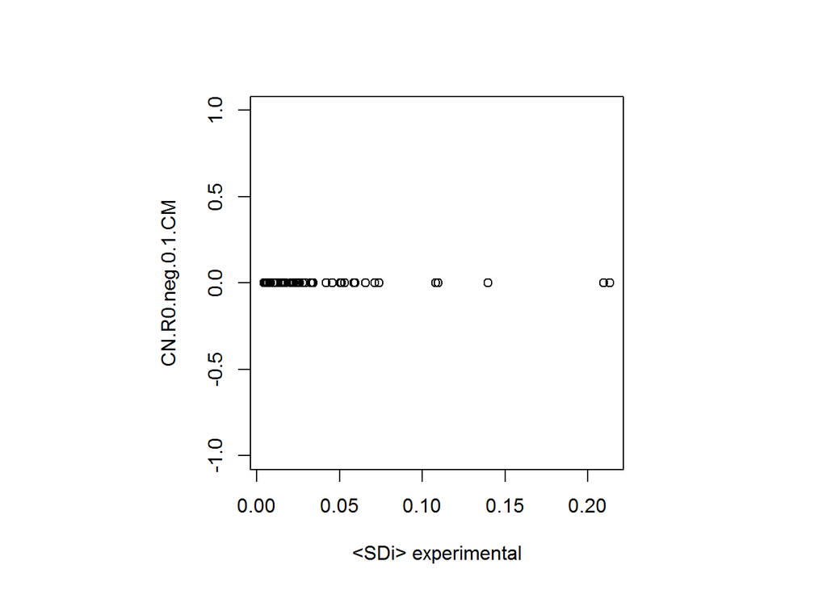

Pearson Correlation structure (SDi) - sequence (CN)

| comparison | R |
| --- | --- |
| experimental vs CN | NA |

Pearson Correlation sqrt structure (SDi) - sqrt sequence (CN)

| comparison | R |
| --- | --- |
| experimental vs CN | NA |

Spearman Correlation structure (SDi) - sequence (CN)

| comparison | R |
| --- | --- |
| experimental vs CN | NA |

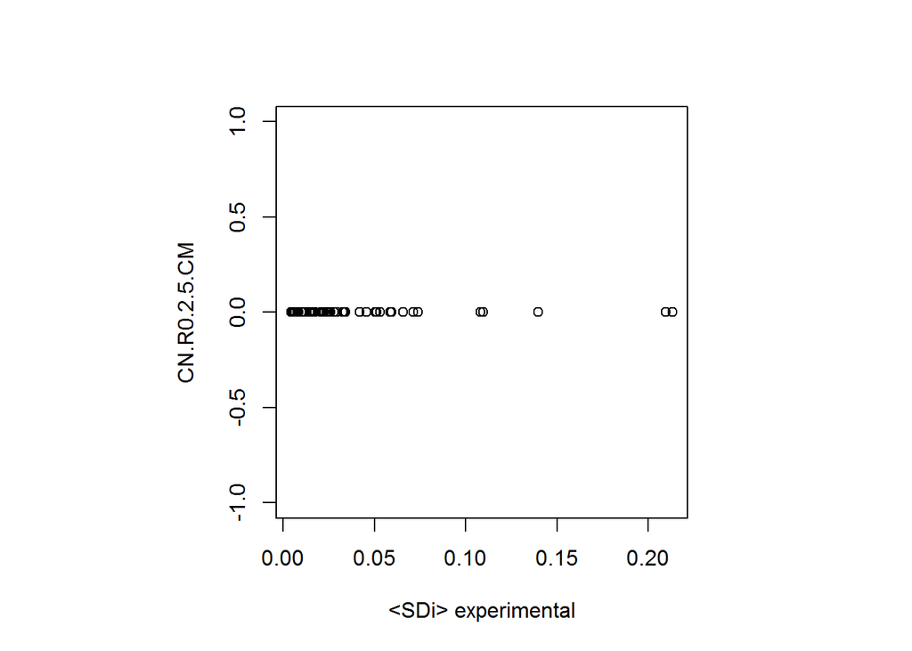

Pearson Correlation structure (SDi) - sequence (CN)

| comparison | R |
| --- | --- |
| experimental vs CN | NA |

Pearson Correlation sqrt structure (SDi) - sqrt sequence (CN)

| comparison | R |
| --- | --- |
| experimental vs CN | NA |

Spearman Correlation structure (SDi) - sequence (CN)

| comparison | R |
| --- | --- |
| experimental vs CN | NA |

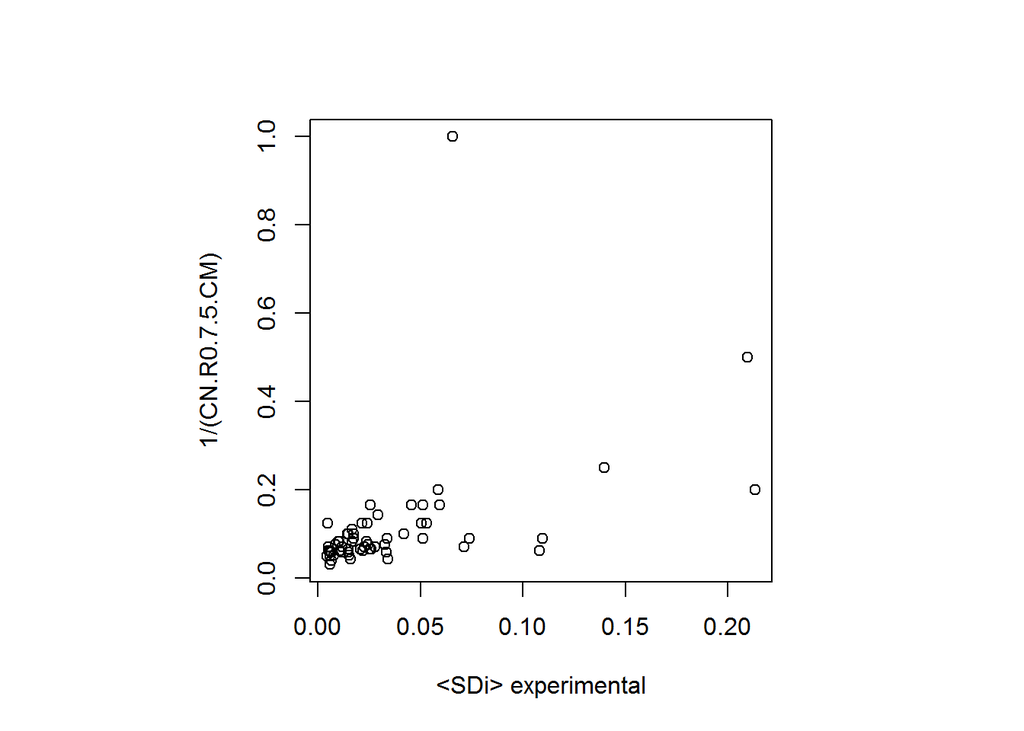

Pearson Correlation structure (SDi) - sequence (CN)

| comparison | R |
| --- | --- |
| experimental vs 1/(CN) | 0.45 |

Pearson Correlation sqrt structure (SDi) - sqrt sequence (CN)

| comparison | R |
| --- | --- |
| experimental vs CN | 0.57 |

Spearman Correlation structure (SDi) - sequence (CN)

| comparison | R |
| --- | --- |
| experimental vs 1/(CN) | 0.59 |

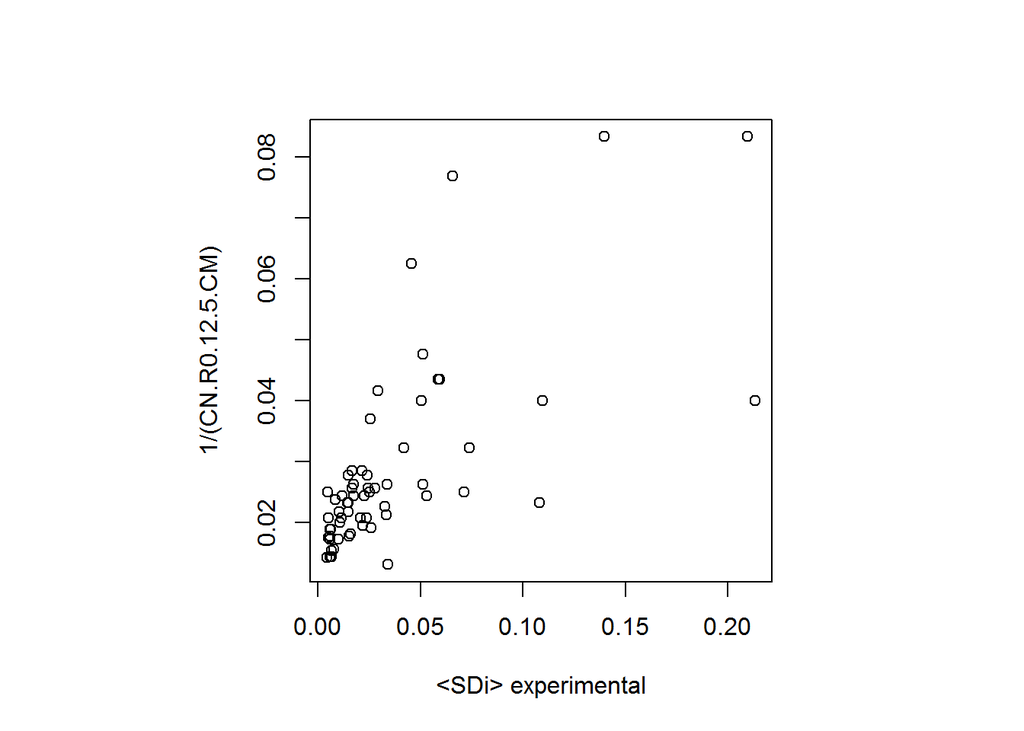

Pearson Correlation structure (SDi) - sequence (CN)

| comparison | R |
| --- | --- |
| experimental vs 1/(CN) | 0.69 |

Pearson Correlation sqrt structure (SDi) - sqrt sequence (CN)

| comparison | R |
| --- | --- |
| experimental vs CN | 0.73 |

Spearman Correlation structure (SDi) - sequence (CN)

| comparison | R |
| --- | --- |
| experimental vs 1/(CN) | 0.72 |

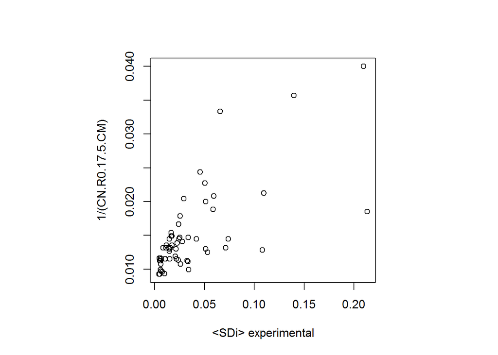

Pearson Correlation structure (SDi) - sequence (CN)

| comparison | R |
| --- | --- |
| experimental vs 1/(CN) | 0.7 |

Pearson Correlation sqrt structure (SDi) - sqrt sequence (CN)

| comparison | R |
| --- | --- |
| experimental vs CN | 0.72 |

Spearman Correlation structure (SDi) - sequence (CN)

| comparison | R |
| --- | --- |
| experimental vs 1/(CN) | 0.66 |

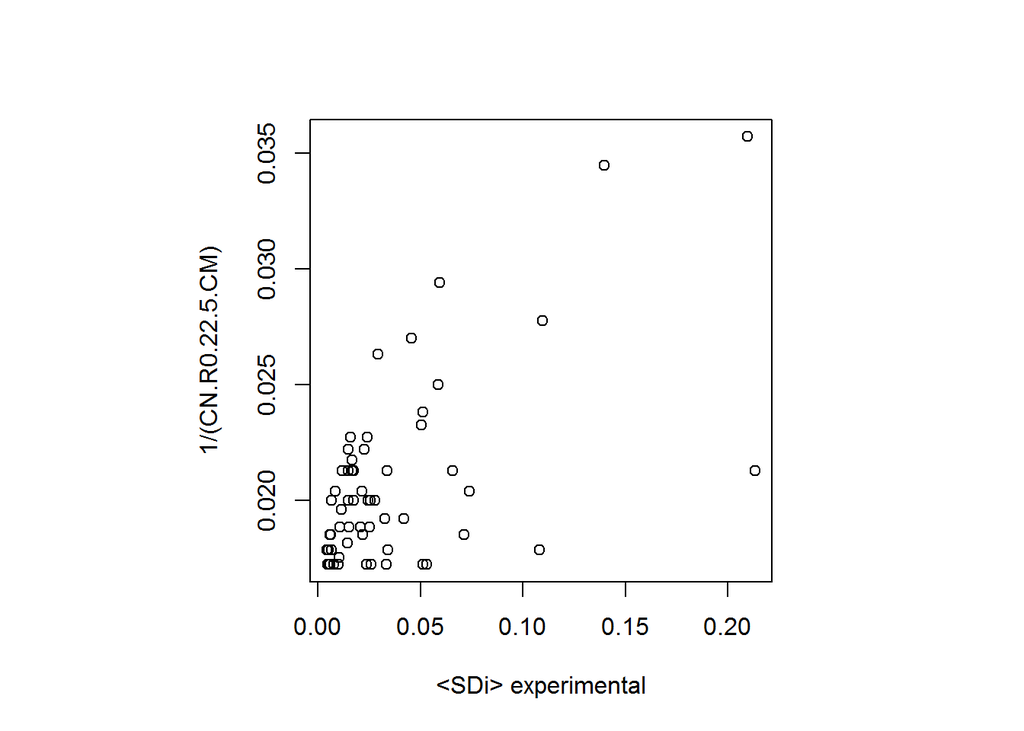

Pearson Correlation structure (SDi) - sequence (CN)

| comparison | R |
| --- | --- |
| experimental vs 1/(CN) | 0.61 |

Pearson Correlation sqrt structure (SDi) - sqrt sequence (CN)

| comparison | R |
| --- | --- |
| experimental vs CN | 0.61 |

Spearman Correlation structure (SDi) - sequence (CN)

| comparison | R |
| --- | --- |
| experimental vs 1/(CN) | 0.47 |

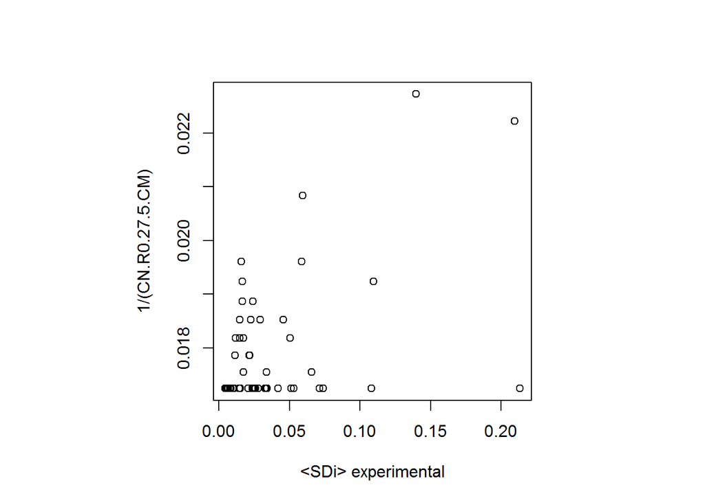

Pearson Correlation structure (SDi) - sequence (CN)

| comparison | R |
| --- | --- |
| experimental vs 1/(CN) | 0.5 |

Pearson Correlation sqrt structure (SDi) - sqrt sequence (CN)

| comparison | R |
| --- | --- |
| experimental vs CN | 0.49 |

Spearman Correlation structure (SDi) - sequence (CN)

| comparison | R |
| --- | --- |
| experimental vs 1/(CN) | 0.32 |

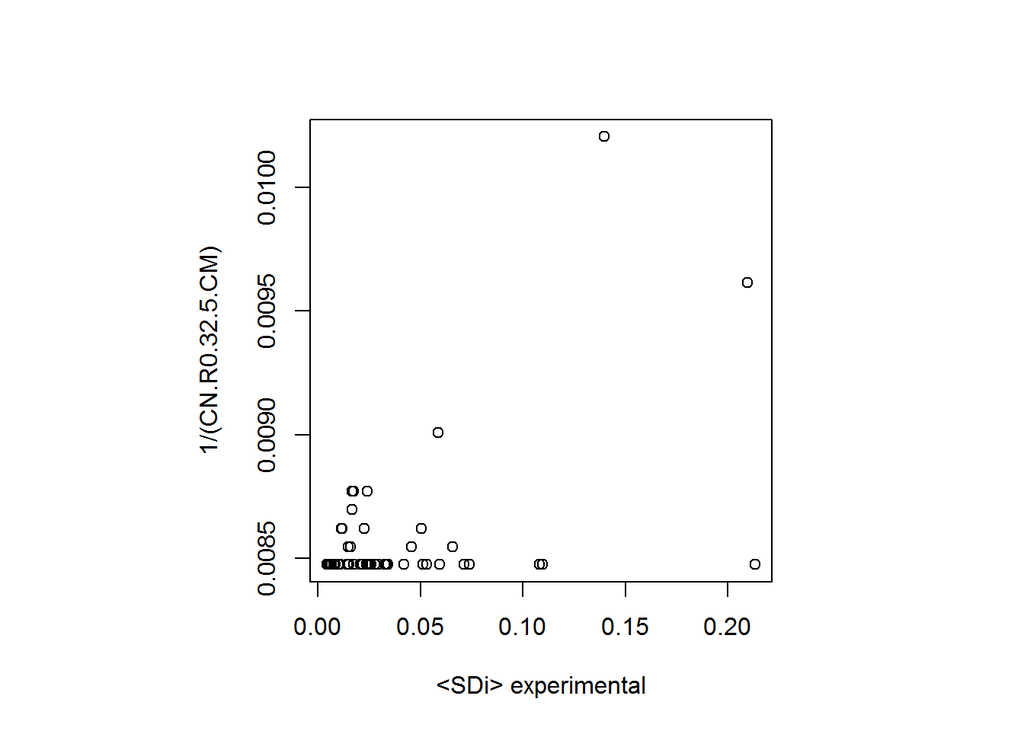

Pearson Correlation structure (SDi) - sequence (CN)

| comparison | R |
| --- | --- |
| experimental vs 1/(CN) | 0.52 |

Pearson Correlation sqrt structure (SDi) - sqrt sequence (CN)

| comparison | R |
| --- | --- |
| experimental vs CN | 0.48 |

Spearman Correlation structure (SDi) - sequence (CN)

| comparison | R |
| --- | --- |
| experimental vs 1/(CN) | 0.2 |

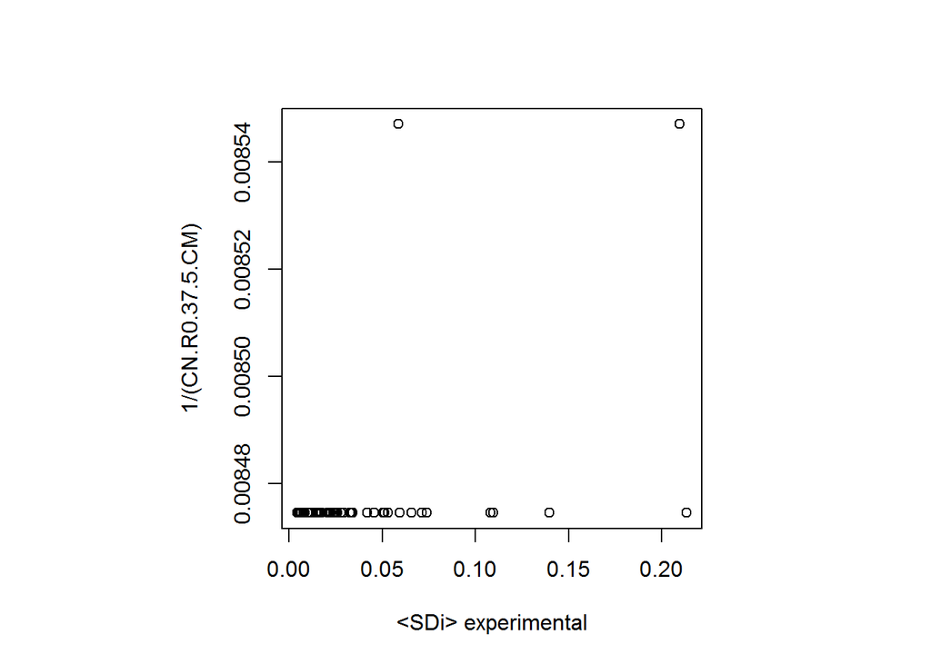

Pearson Correlation structure (SDi) - sequence (CN)

| comparison | R |
| --- | --- |
| experimental vs 1/(CN) | 0.43 |

Pearson Correlation sqrt structure (SDi) - sqrt sequence (CN)

| comparison | R |
| --- | --- |
| experimental vs CN | 0.39 |

Spearman Correlation structure (SDi) - sequence (CN)

| comparison | R |
| --- | --- |
| experimental vs 1/(CN) | 0.26 |

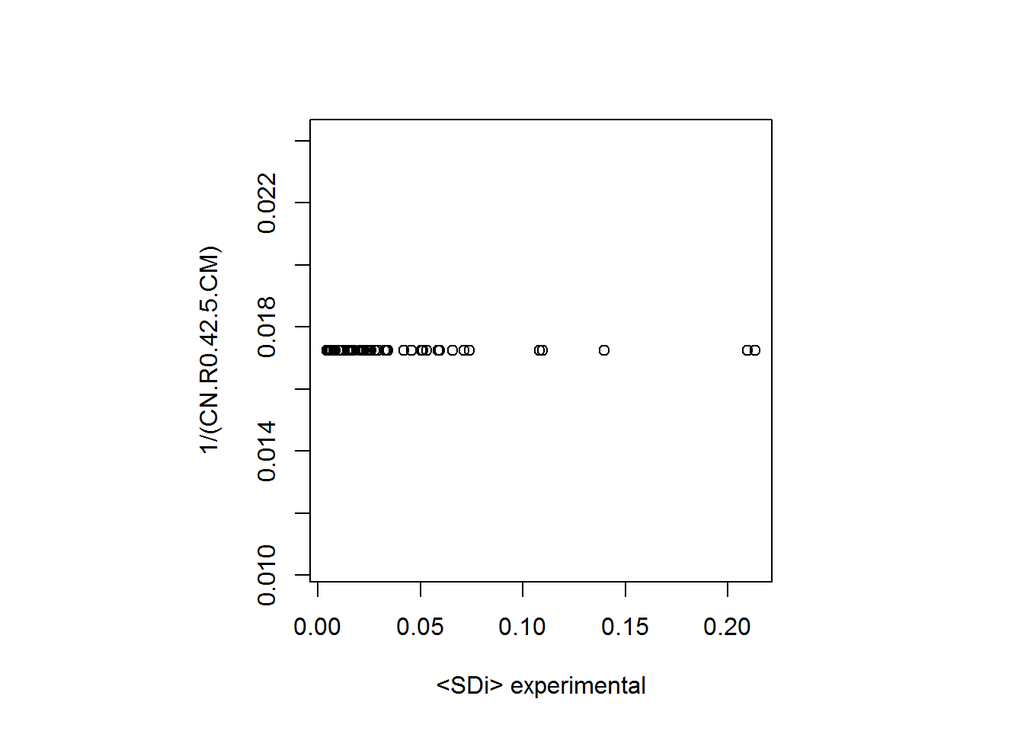

Pearson Correlation structure (SDi) - sequence (CN)

| comparison | R |
| --- | --- |
| experimental vs 1/(CN) | NA |

Pearson Correlation sqrt structure (SDi) - sqrt sequence (CN)

| comparison | R |
| --- | --- |
| experimental vs CN | NA |

Spearman Correlation structure (SDi) - sequence (CN)

| comparison | R |
| --- | --- |
| experimental vs 1/(CN) | NA |

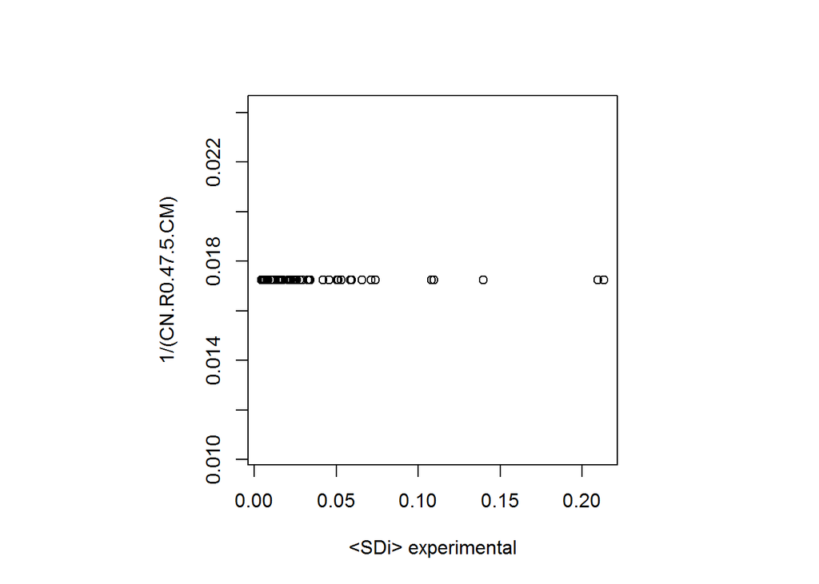

Pearson Correlation structure (SDi) - sequence (CN)

| comparison | R |
| --- | --- |
| experimental vs 1/(CN) | NA |

Pearson Correlation sqrt structure (SDi) - sqrt sequence (CN)

| comparison | R |
| --- | --- |
| experimental vs CN | NA |

Spearman Correlation structure (SDi) - sequence (CN)

| comparison | R |
| --- | --- |
| experimental vs 1/(CN) | NA |

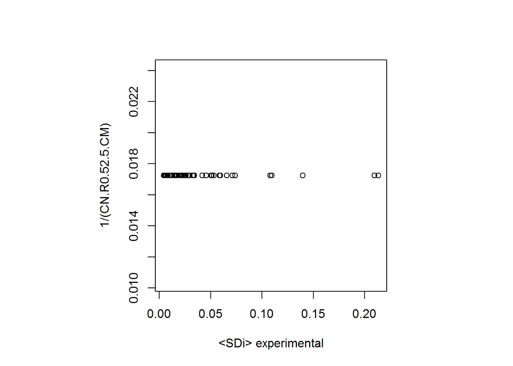

Pearson Correlation structure (SDi) - sequence (CN)

| comparison | R |
| --- | --- |
| experimental vs 1/(CN) | NA |

Pearson Correlation sqrt structure (SDi) - sqrt sequence (CN)

| comparison | R |
| --- | --- |
| experimental vs CN | NA |

Spearman Correlation structure (SDi) - sequence (CN)

| comparison | R |
| --- | --- |
| experimental vs 1/(CN) | NA |

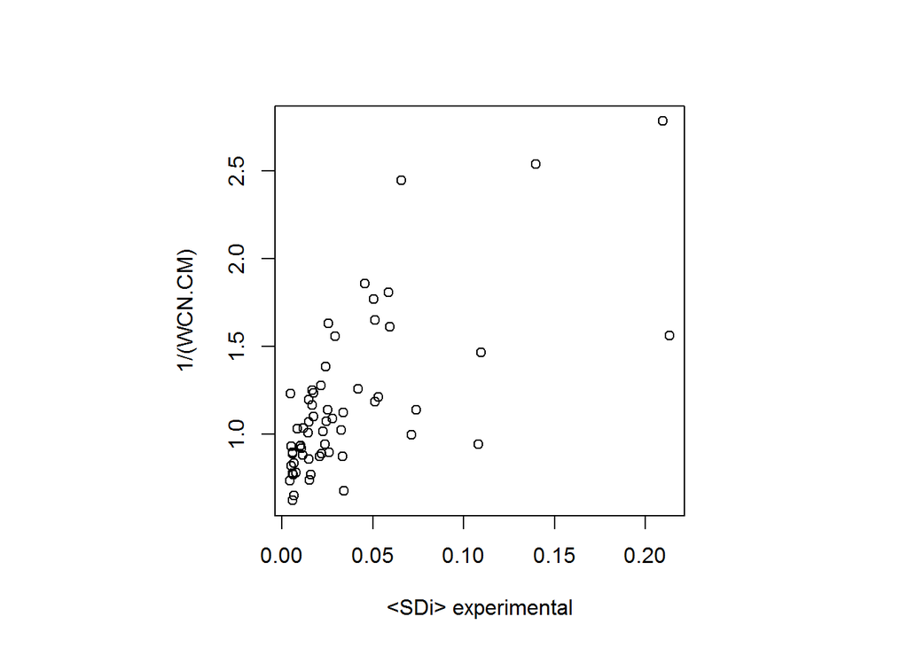

Pearson Correlation structure (SDi) - sequence (WCN)

| comparison | R |
| --- | --- |
| experimental vs 1/(WCN) | 0.68 |

Pearson Correlation sqrt structure (SDi) - sqrt sequence (WCN)

| comparison | R |
| --- | --- |
| experimental vs 1/(WCN) | 0.71 |

Spearman Correlation structure (SDi) - sequence (WCN)

| comparison | R |
| --- | --- |
| experimental vs 1/(WCN) | 0.66 |

### All correlations

Correlation structure (exp SDi) - sequence 1/(CN/WCN)

|  | CA.pearson | CA.pearson.sqrt | CM.pearson | CM.pearson.sqrt | CA.spearman | CM.spearman |
| --- | --- | --- | --- | --- | --- | --- |
| CN R0 = -0.1 | NA | NA | NA | NA | NA | NA |
| CN R0 = 2.5 | NA | NA | NA | NA | NA | NA |
| CN R0 = 7.5 | 0.65 | 0.70 | 0.45 | 0.57 | 0.68 | 0.59 |
| CN R0 = 12.5 | 0.74 | 0.77 | 0.69 | 0.73 | 0.75 | 0.72 |
| CN R0 = 17.5 | 0.71 | 0.72 | 0.70 | 0.72 | 0.64 | 0.66 |
| CN R0 = 22.5 | 0.61 | 0.61 | 0.61 | 0.61 | 0.47 | 0.47 |
| CN R0 = 27.5 | 0.50 | 0.49 | 0.50 | 0.49 | 0.32 | 0.32 |
| CN R0 = 32.5 | 0.50 | 0.45 | 0.52 | 0.48 | 0.25 | 0.20 |
| CN R0 = 37.5 | NA | NA | 0.43 | 0.39 | NA | 0.26 |
| CN R0 = 42.5 | NA | NA | NA | NA | NA | NA |
| CN R0 = 47.5 | NA | NA | NA | NA | NA | NA |
| CN R0 = 52.5 | NA | NA | NA | NA | NA | NA |
| WCN | 0.71 | 0.76 | 0.68 | 0.71 | 0.74 | 0.66 |